# class_numpy

## Python for Data Analysis book

Chapter 4

Introduction to Numpy

-- Then we'll talk about your exam!

## Numpy: Numerical Python

Numpy is a core library built and used as the backbone of most high level scientific and numerical analysis packages.

Numpy provides data structures and functionality

[figure not shown]

ndarray: an efficient multi-dimensional

array providing fast array-oriented arithmetic operations and flexible broadcasting capabilities.

Mathematical functions for fast operations on entire arrays of data without having to write loops

Tools for reading/writing array data to disk and working with memory-mapped files

Linear Algebra, random number generation, Fourier transform capabilities

A C API for connecting NumPy with libraries written in C, C++ and FORTRAN

Numpy stores data efficiently by keepign it in contiguous blocks of memory, independent of other Python objects

```python
# Import the numpy library, aliasing it to np..  Not sure why we always do that
import numpy as np
```

```python
data = np.random.randn(2,3)
```

```python
data
```

```
array([[-2.13048994, -0.93506454,  0.07414567],
       [ 0.03039112,  1.68584412,  1.89978145]])
```

```python
# multiply each item in the array by 10
data * 10
```

```
array([[-21.30489941,  -9.35064543,   0.74145669],
       [  0.30391115,  16.85844124,  18.99781448]])
```

```python
# Add data to data (adding two multi dimension arrays)
data + data
```

```
array([[-4.26097988, -1.87012909,  0.14829134],
       [ 0.06078223,  3.37168825,  3.7995629 ]])
```

```python
# size of dimensions
data.shape
```

```
(2, 3)
```

```python
# Data type stored in array
data.dtype
```

```
dtype('float64')
```

From the book, they refer to a 'ndarray' object multiple ways:

1. Array
2. NumPy array
3. ndarray

```python
#Create arrays
list_data1 = [6, 7.5, 8, 0, 1]
ndarray_data1 = np.array(list_data1)
```

```python
ndarray_data1
```

```
array([6. , 7.5, 8. , 0. , 1. ])
```

```python
ndarray_data1.shape
```

```
(5,)
```

```python
ndarray_data1.dtype
```

```
dtype('float64')
```

```python
# Create a multi dimensional array
list_data2 = [[1, 2, 3, 4], [5, 6, 7, 8]]
ndarray_data2 = np.array(list_data2)
```

```python
ndarray_data2
```

```
array([[1, 2, 3, 4],
       [5, 6, 7, 8]])
```

```python
ndarray_data2.dtype
```

```
dtype('int64')
```

```python
ndarray_data2.ndim
```

```
2
```

```python
ndarray_data2.shape
```

```
(2, 4)
```

dtype is an 'inferred' meta data attribute of the array

numpy tries to guess based on the data in the array

Numpy has a suite of functions for creating new arrays

```python
# Create an array with a lot of zeros
np.zeros(10)
```

```
array([0., 0., 0., 0., 0., 0., 0., 0., 0., 0.])
```

```python
np.zeros((3, 6))
```

```
array([[0., 0., 0., 0., 0., 0.],
       [0., 0., 0., 0., 0., 0.],
       [0., 0., 0., 0., 0., 0.]])
```

```python
np.empty((2,3,2))
```

```
array([[[0.00000000e+000, 0.00000000e+000],
        [0.00000000e+000, 0.00000000e+000],
        [0.00000000e+000, 0.00000000e+000]],

       [[0.00000000e+000, 0.00000000e+000],
        [0.00000000e+000, 0.00000000e+000],
        [0.00000000e+000, 5.24862813e+170]]])
```

# ** WARNING *

It's not safe to assume that np.empty will return an array of all zeros. In some cases, it may return uninitialized 'garbage' values. Unitialized garbage means: Whatever was already in memory.

```python
# arange:  numpy , array value of the built in range function
for x in range(10):
    print(x)
```

```
0
1
2
3
4
5
6
7
8
9
```

```python
np.arange(15)
```

```
array([ 0,  1,  2,  3,  4,  5,  6,  7,  8,  9, 10, 11, 12, 13, 14])
```

- array
- asarray
- arange
- ones,
- ones_like # duplicates the structure/shape of an existing array
- zeros,
- zeros_like
- empty,
- empty_like
- full,
- full_like
- eye, identity # Create a square N * N identity matrix (1s on the diagonal, 0s elsewhere)

```python
np.eye(12)
```

```
array([[1., 0., 0., 0., 0., 0., 0., 0., 0., 0., 0., 0.],
       [0., 1., 0., 0., 0., 0., 0., 0., 0., 0., 0., 0.],
       [0., 0., 1., 0., 0., 0., 0., 0., 0., 0., 0., 0.],
       [0., 0., 0., 1., 0., 0., 0., 0., 0., 0., 0., 0.],
       [0., 0., 0., 0., 1., 0., 0., 0., 0., 0., 0., 0.],
       [0., 0., 0., 0., 0., 1., 0., 0., 0., 0., 0., 0.],
       [0., 0., 0., 0., 0., 0., 1., 0., 0., 0., 0., 0.],
       [0., 0., 0., 0., 0., 0., 0., 1., 0., 0., 0., 0.],
       [0., 0., 0., 0., 0., 0., 0., 0., 1., 0., 0., 0.],
       [0., 0., 0., 0., 0., 0., 0., 0., 0., 1., 0., 0.],
       [0., 0., 0., 0., 0., 0., 0., 0., 0., 0., 1., 0.],
       [0., 0., 0., 0., 0., 0., 0., 0., 0., 0., 0., 1.]])
```

```python
np.identity(12)
```

```
array([[1., 0., 0., 0., 0., 0., 0., 0., 0., 0., 0., 0.],
       [0., 1., 0., 0., 0., 0., 0., 0., 0., 0., 0., 0.],
       [0., 0., 1., 0., 0., 0., 0., 0., 0., 0., 0., 0.],
       [0., 0., 0., 1., 0., 0., 0., 0., 0., 0., 0., 0.],
       [0., 0., 0., 0., 1., 0., 0., 0., 0., 0., 0., 0.],
       [0., 0., 0., 0., 0., 1., 0., 0., 0., 0., 0., 0.],
       [0., 0., 0., 0., 0., 0., 1., 0., 0., 0., 0., 0.],
       [0., 0., 0., 0., 0., 0., 0., 1., 0., 0., 0., 0.],
       [0., 0., 0., 0., 0., 0., 0., 0., 1., 0., 0., 0.],
       [0., 0., 0., 0., 0., 0., 0., 0., 0., 1., 0., 0.],
       [0., 0., 0., 0., 0., 0., 0., 0., 0., 0., 1., 0.],
       [0., 0., 0., 0., 0., 0., 0., 0., 0., 0., 0., 1.]])
```

```python
"""
You can explicitly tell an ndarray what data type to have inside of it.
done with a parameter for the different functions
"""
np.array([1,2,3], dtype=np.float64)
```

```
array([1., 2., 3.])
```

```python
np.array([1,2,3], dtype=np.float64).dtype
```

```
dtype('float64')
```

```python
np.array([1,2,3], dtype=np.int32)
```

```
array([1, 2, 3], dtype=int32)
```

```python
np.array([1,2,3], dtype=np.int32).dtype
```

```
dtype('int32')
```

## Numpy supports a wide range of data types, but you don't have to memorize each and everyone

- int (8/16/32/64)
- float (16, 32, 64, 128)
- complex (64, 128, 256) - complex type represented by two numbers
- bool
- object
- string_ (fixed size ascii, S abbreviation , S10)
- unicode_ (fixed size Unicode, U abbreviation, U12)

```python
"""
We can explicitly cast/convert some dtypes to others
"""
int_arr = np.array([1,2,3,4])
int_arr
```

```
array([1, 2, 3, 4])
```

```python
int_arr.dtype
```

```
dtype('int64')
```

```python
float_arr = int_arr.astype(np.float64)
float_arr
```

```
array([1., 2., 3., 4.])
```

```python
float_arr.dtype
```

```
dtype('float64')
```

I'm skipping a bunch of information on 'slicing' the array and other utilities like 'resizing'

Please read chapter 4.1 in your book. That material CAN be used in a quiz.

# UNARY Functions

Functions that act on one ndarray

- exp - calculate the exponential of each number
- sqrt - square root
- exp2 - 2**x
- abs, fabs
- square
- log, log10, log2, log1p
- sign
- ceil
- floor
- rint
- modf
- isnan
- isfinite, isinf
- cos, cosh, sin, sinh, tan, tanh
- arccos, archosh, arcsin, arcsignh, arctan, arctanh
- logical_not

```python
int_arr2 = np.arange(12, dtype=np.int32)
int_arr2
```

```
array([ 0,  1,  2,  3,  4,  5,  6,  7,  8,  9, 10, 11], dtype=int32)
```

```python
np.exp2(int_arr2)
```

```
array([1.000e+00, 2.000e+00, 4.000e+00, 8.000e+00, 1.600e+01, 3.200e+01,
       6.400e+01, 1.280e+02, 2.560e+02, 5.120e+02, 1.024e+03, 2.048e+03])
```

```python
np.exp2(int_arr2).dtype
```

```
dtype('float64')
```

```python
np.exp2(int_arr2).astype(np.int32)
```

```
array([   1,    2,    4,    8,   16,   32,   64,  128,  256,  512, 1024,
       2048], dtype=int32)
```

# BINARY Functions

Functions that act on TWO ndarrays

- add
- subtract
- multiply
- divide, floor_divide
- power
- maximum, fmax - (fmax ignore NaN)
- minimum, fmin - (fmin ignores NaN)
- mod - modulus
- copysign - copies sign of second argument to first
- greater, greater_equal, less, less_equal, equal, not_equal
- logical_and, logical_or, logical_xor

```python
first_arr = np.array([1,2,3,4])
second_arr = np.array([1,2,3,4])
np.add(first_arr, second_arr)
```

```
array([2, 4, 6, 8])
```

```python
first_arr = np.array([1,2,3,4])
second_arr = np.array([10,20,30,40])
np.subtract(first_arr, second_arr)
```

```
array([ -9, -18, -27, -36])
```

```python
np.subtract(second_arr, first_arr)
```

```
array([ 9, 18, 27, 36])
```

```python
first_arr
```

```
array([1, 2, 3, 4])
```

```python
second_arr
```

```
array([10, 20, 30, 40])
```

```python
third_arr = np.subtract(second_arr, first_arr)
```

```python
third_arr
```

```
array([ 9, 18, 27, 36])
```

## Fun visualization, if we get this far.

[figure not shown]

```python
import matplotlib.pyplot as plt
points = np.arange(-5, 5, 0.01)
xs, ys = np.meshgrid(points, points)
```

```python
xs
```

```
array([[-5.  , -4.99, -4.98, ...,  4.97,  4.98,  4.99],
       [-5.  , -4.99, -4.98, ...,  4.97,  4.98,  4.99],
       [-5.  , -4.99, -4.98, ...,  4.97,  4.98,  4.99],
       ...,
       [-5.  , -4.99, -4.98, ...,  4.97,  4.98,  4.99],
       [-5.  , -4.99, -4.98, ...,  4.97,  4.98,  4.99],
       [-5.  , -4.99, -4.98, ...,  4.97,  4.98,  4.99]])
```

```python
ys
```

```
array([[-5.  , -5.  , -5.  , ..., -5.  , -5.  , -5.  ],
       [-4.99, -4.99, -4.99, ..., -4.99, -4.99, -4.99],
       [-4.98, -4.98, -4.98, ..., -4.98, -4.98, -4.98],
       ...,
       [ 4.97,  4.97,  4.97, ...,  4.97,  4.97,  4.97],
       [ 4.98,  4.98,  4.98, ...,  4.98,  4.98,  4.98],
       [ 4.99,  4.99,  4.99, ...,  4.99,  4.99,  4.99]])
```

```python
z = np.sqrt(xs ** 2 + ys **2)
```

z

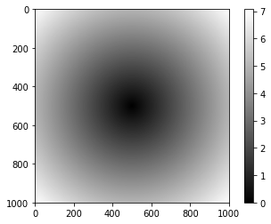

```python
plt.imshow(z, cmap=plt.cm.gray)
plt.colorbar()
```

```python
new_xs = np.arange(10)
new_xs
```

```
array([0, 1, 2, 3, 4, 5, 6, 7, 8, 9])
```

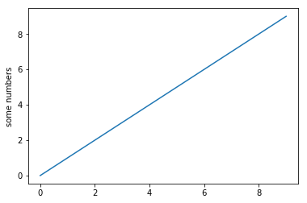

```python
plt.plot(new_xs)
plt.ylabel('some numbers')
plt.show()
```

```python
np.power(new_xs, 2)
```

```
array([ 0,  1,  4,  9, 16, 25, 36, 49, 64, 81])
```

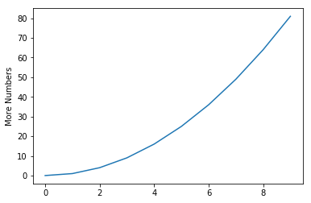

```python
plt.plot(np.power(new_xs, 2))
plt.ylabel("More Numbers")
plt.show()
```

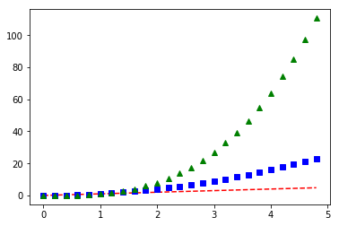

```python
t = np.arange(0., 5., 0.2)

# red dashes, blue squares and green triangles
"""
t, t, "r--"  # x=t, y=t, red dashes
t, t**2, "bs" # x = t, y = t squared, blue square
t, t**3, g^ # x = t, y = t ^3, green triangles]
"""
plt.plot(t, t, 'r--', t, t**2, 'bs', t, t**3, 'g^')
plt.show()
```

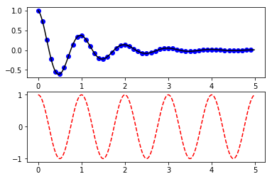

```python
def f(t):
    return np.exp(-t) * np.cos(2*np.pi*t)

t1 = np.arange(0.0, 5.0, 0.1)
t2 = np.arange(0.0, 5.0, 0.02)

plt.figure()
plt.subplot(211)
plt.plot(t1, f(t1), 'bo', t2, f(t2), 'k')

plt.subplot(212)
plt.plot(t2, np.cos(2*np.pi*t2), 'r--')
plt.show()
```

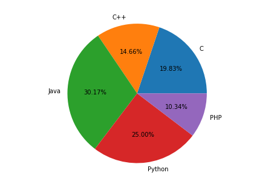

```python
from matplotlib import pyplot as plt
import numpy as np
fig = plt.figure()
ax = fig.add_axes([0,0,1,1])
ax.axis('equal')
langs = ['C', 'C++', 'Java', 'Python', 'PHP']
students = [23,17,35,29,12]
ax.pie(students, labels = langs,autopct='%1.2f%%')
plt.show()
```

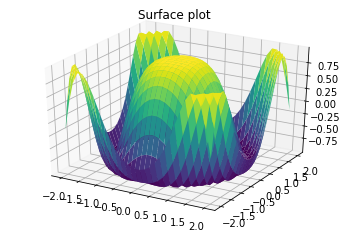

```python
from mpl_toolkits import mplot3d
import numpy as np
import matplotlib.pyplot as plt
x = np.outer(np.linspace(-2, 2, 30), np.ones(30))
y = x.copy().T # transpose
z = np.cos(x ** 2 + y ** 2)

fig = plt.figure()
ax = plt.axes(projection='3d')

ax.plot_surface(x, y, z,cmap='viridis', edgecolor='none')
ax.set_title('Surface plot')
plt.show()
```

https://www.tutorialspoint.com/matplotlib/matplotlib_3d_contour_plot.htm